# DataScaleCheck

**Author**: Shouye Liu  
**Date**: 2025-03-21  
**Description**: Diagnose scale issue of summary statistics

```r
suppressPackageStartupMessages(library(tidyverse))
library(data.table)
library(ggplot2)
library(patchwork)
```

In an association of a single SNP $j$, we have a simple linear model ([Yang, Jian, et al(2012)](https://www.nature.com/articles/ng.2213)): $$y = X_jb_j + e \tag{1}$$ Based on OLS, we have $$\hat{b}_j = (X_j^TX_j)^{-1}X_j^Ty = D_j^{-1}X_j^Ty\tag{2}$$ and $$\sigma_b^2 = \sigma_e^2 (X_j^TX_j)^{-1} = \sigma_e^2D_j^{-1}\tag{3}$$ Based on ANOVA, we have $$\sigma_e^2 = \frac{y^Ty - \hat{y}^T\hat{y}}{(n-1)} = \frac{y^Ty - (X_j\hat{b}_j)^T(X_j\hat{b}_j)}{(n-1)} \tag{4}$$ Based on probability, we have Z-score $$z_j = \frac{\hat{b}_j}{\sigma_b}\tag{5}$$ Reformatting Eq(4), we derive $$(n-1)\sigma_e^2 = y^Ty - \hat{b}_j^2D_j \tag{6}$$ By combining Eq(3) and Eq(5) into Eq(6), we have $$\begin{aligned}(n-1)\sigma_b^2D_j &= y^Ty - z_j^2\sigma_b^2D_j \\ \Leftrightarrow \sigma_b &= \sqrt{\frac{y^Ty}{(n-1)D_j+z_j^2D_j}}\end{aligned}\tag{7}$$ Here, we assume trait phenotype $y$ is standardized (thus, $y^Ty = n$) and $D_j = 2p_j(1-p_j)n$. If only summary statistics Z score is provided, we can re-estimate $\hat{b}_j$ and $\sigma_b$ given allele frequency $p$, sample size $n$ and zscore $z$, therefore, $$\begin{aligned}\sigma_b &= \sqrt{\frac{n}{(n-1)2p_j(1-p_j)n+z_j^22p_j(1-p_j)n}} \\ &= \sqrt{\frac{1}{(n-1)2p_j(1-p_j)+z_j^22p_j(1-p_j)}}\end{aligned}\tag{8}$$ Also, we have $$b_j = \sqrt{\frac{z^2}{(n-1)2p_j(1-p_j)+z_j^22p_j(1-p_j)}}\tag{9}$$

A data.table: 6 x 18

| GeneID <chr> | GeneChr <int> | GeneLength <int> | GenePhyPos <dbl> | SNPID <chr> | SNPChr <int> | SNPPhyPos <int> | A1 <chr> | A2 <chr> | A1Freq <dbl> | BETA <dbl> | SE <dbl> | Pvalue <dbl> | N <int> | zz <dbl> | beta <dbl> | betaScale <dbl> | se <dbl> |
| --- | --- | --- | --- | --- | --- | --- | --- | --- | --- | --- | --- | --- | --- | --- | --- | --- | --- |
| ENSG00000187905 | 22 | -999 | 21409346 | rs428214 | 22 | 21361060 | T | G | 0.155100 | -0.006123455 | 0.008735706 | 4.833227e-01 | 50000 | -0.7009685 | -0.006123393 | -0.003134874 | 0.008735618 |
| ENSG00000187905 | 22 | -999 | 21409346 | rs373092 | 22 | 21361870 | G | T | 0.027860 | -0.511740506 | 0.019078813 | 2.225000e-308 | 50000 | -26.8224492 | -0.511735459 | -0.119102192 | 0.019078625 |
| ENSG00000187905 | 22 | -999 | 21409346 | rs398577 | 22 | 21362849 | A | C | 0.139213 | -0.275573105 | 0.009060138 | 2.225000e-308 | 50000 | -30.4159945 | -0.275319807 | -0.134908581 | 0.009051810 |
| ENSG00000187905 | 22 | -999 | 21409346 | rs2075274 | 22 | 21363306 | A | G | 0.371860 | -0.301651835 | 0.006405235 | 2.225000e-308 | 50000 | -47.0945754 | -0.301531294 | -0.206176388 | 0.006402676 |
| ENSG00000187905 | 22 | -999 | 21409346 | rs2516542 | 22 | 21363505 | T | C | 0.126070 | -0.342185229 | 0.009403473 | 2.225000e-308 | 50000 | -36.3892402 | -0.342181893 | -0.160627706 | 0.009403381 |
| ENSG00000187905 | 22 | -999 | 21409346 | rs2075276 | 22 | 21363744 | C | T | 0.498304 | -0.434683323 | 0.006030275 | 2.225000e-308 | 50000 | -72.0834933 | -0.433913672 | -0.307365757 | 0.006019598 |

```
[1] "correlation between beta and BETA is 0.999999335847599"
[1] "correlation between beta and betaScale is 0.957713529698195"
```

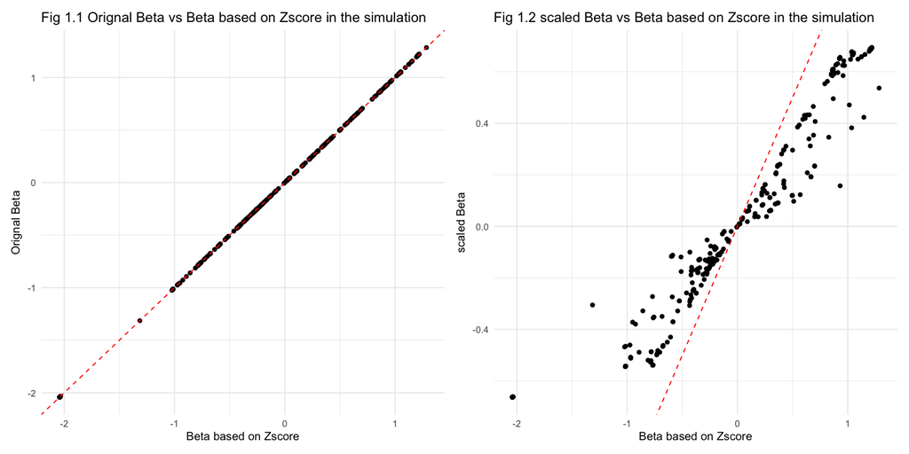

```r
############################################
### Run a simulation to simulate gene exression
### y = beta * x + e, where y is scaled gene expression
### x is the genotype at 0/1/2 scale, BETA and SE
###  is the original effect size and standard error
###  N is the sample size
###  A1Freq is the allele frequency
###  zz is the zscore
############################################
set.seed(1234)
sumPath = "~/Documents/personal/SbayesAnno/downSampling/Verify0319/summary/"
smrIndFileSuffix = "ukbg-chr22-causal-model-50k-ind"
geneLDFile = paste0(sumPath,smrIndFileSuffix)
xqtl = fread(paste0(geneLDFile,".q.query.gz"))
test = xqtl %>% mutate(zz = BETA/SE) %>%
mutate(beta = zz / sqrt(2 * A1Freq * (1-A1Freq) * (N-1 + zz^2)),
       betaScale = BETA * sqrt(2 * A1Freq * (1-A1Freq)),
se = 1 / sqrt(2 * A1Freq * (1-A1Freq) * (N-1 + zz^2))
)
head(test)
options(repr.plot.width = 12, repr.plot.height = 6)
#### beta based on zscore and Original beta
p1 = ggplot(test, aes(x = beta, y = BETA,)) +
  geom_point() +
  geom_abline(intercept = 0, slope = 1, linetype = "dashed", color = "red") +
  labs(
    y = "Orignal Beta",
    x = "Beta based on Zscore",
    title = "Fig 1.1 Orignal Beta vs Beta based on Zscore in the simulation"
  ) + theme_minimal();
  #### beta based on zscore and Original beta
p2 = ggplot(test, aes(x = beta, y = betaScale)) +
  geom_point() +
  geom_abline(intercept = 0, slope = 1, linetype = "dashed", color = "red") +
  labs(
    x = "Beta based on Zscore",
    y = "scaled Beta",
    title = "Fig 1.2 scaled Beta vs Beta based on Zscore in the simulation"
  ) + theme_minimal();
(p1 + p2)
print(paste0("correlation between beta and BETA is ", cor(test$beta, test$BETA)))
print(paste0("correlation between beta and betaScale is ", cor(test$beta, test$betaScale)))
```